# MATH 3080 Lab Project 10

Harrison Webb

04/06/2022

```r
#Sign Test Code by Julie Sherman
sign.test <- function(x, q = 0, p = 0.5, alternative = "two.sided") {
  res <- list()
  res$data.name <- deparse(substitute(x))
  res$estimate <- c("quantile" = quantile(x, p)[[1]])
  x <- x[x != q]  # Delete observations matching q exactly
  res$method <- "Sign Test"
  res$parameter <- c("p" = p)
  res$alternative <- alternative
  res$null.value <- c("quantile" = q)
  res$statistic <- c("T" = sum(x > q))
  n <- length(x)
  res$p.value <- binom.test(res$statistic, n, p = 1 - p,
                            alternative = alternative)$p.value
  class(res) <- "htest"
  res
}
```

# Problem 1 (Verzani problem 9.17)

*The `exec.pay` (**UsingR**) data set contains data on the salaries of CEOs at 199 top companies in the United States. The amounts are in $10,000s. The data is not symmetric. Do a sign test to determine whether the median pay is more than $220,000.*

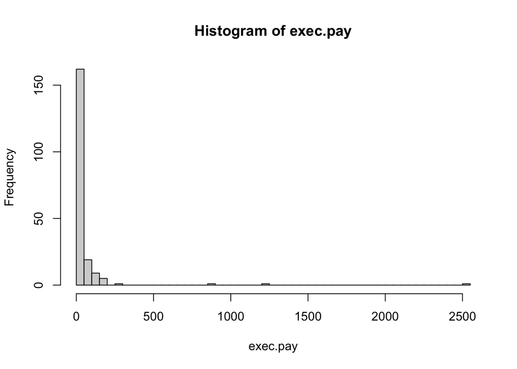

```r
hist(exec.pay, breaks = 40)
```

```r
sign.test(exec.pay, q = 22, alternative = "greater")
```

```
##
##  Sign Test
##
## data:  exec.pay
## T = 113, p = 0.5, p-value = 0.008506
## alternative hypothesis: true quantile is greater than 22
## sample estimates:
## quantile
##       27
```

With a p-value of 0.0085, we have strong statistical evidence to believe that the median pay is more than $220,000.

# Problem 2 (Verzani problem 9.18)

*Repeat the previous exercise, using the signed-rank test on the log-transformed data. Do you reach the same conclusion?*

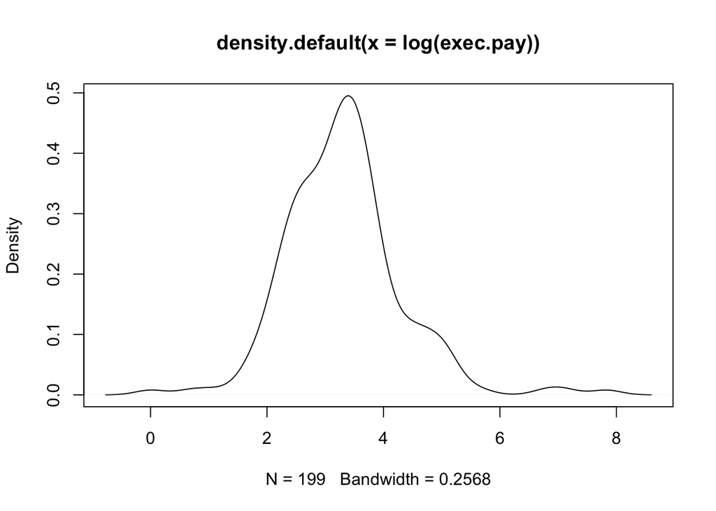

```r
plot(density(log(exec.pay)))
```

```r
execTransform = log(exec.pay)

wilcox.test(execTransform, mu = log(22), alternative = 'greater')
```

```
##
##  Wilcoxon signed rank test with continuity correction
##
## data:  execTransform
## V = 10966, p-value = 0.01366
## alternative hypothesis: true location is greater than 3.091042
```

With the log-transformed data we get a p-value of 0.01366. So, with a significance level of $\alpha = 0.05$, we reject the null hypothesis that true location is $ln(22) \approx 3.09$. However, at a stricter level of $\alpha = 0.01$, we do not reject the null.

# Problem 3 (Verzani problem 9.20)

*If the sign test has fewer assumptions on the population, why wouldn’t we always use that instead of a $t$-test? The answer lies in the power of the sign test to detect when the null hypothesis is false. The sign test will not reject a false null as often as the $t$-test. The following commands will perform a simulation comparing the two tests on data that has a $N(1, 2)$ distribution. The significance tests performed are both*

$$H_0: \mu = 0$$

$$H_A: \mu > 0.$$

*Run the simulation. Is there a big difference between the two tests?*

```r
m <- 200; n <- 10

out <- replicate(m, {
  x <- rnorm(n, mean = 1, sd = 2)
  ttest <- t.test(x, mu = 0, alt = "greater")$p.value
  sgntest <- 1 - pbinom(sum(x > 0) - 1, n, 1/2)
  c(t.test = ifelse(ttest < 0.05, 1, 0),
    sign.test = ifelse(sgntest < 0.05, 1, 0))
})

res.t <- out["t.test",]
res.sign <- out["sign.test",]
results <- c(t = sum(res.t)/m, sign = sum(res.sign) / m)

res.t
```

```
##   [1] 0 1 1 1 0 1 1 0 0 1 0 1 1 1 0 1 0 0 1 0 1 0 0 1 0 0 0 0 0 0 0 0 0 0 1 0 1
##  [38] 0 1 0 0 1 0 0 1 0 0 0 0 1 0 1 0 0 0 1 0 1 1 1 0 1 0 0 0 0 1 1 0 0 1 0 1 1
##  [75] 1 1 1 1 0 1 0 1 0 1 0 0 0 0 0 1 1 1 1 0 1 0 1 0 1 0 1 0 0 0 0 1 1 1 1 0 0
## [112] 1 0 1 0 1 0 0 1 1 0 1 1 0 0 0 0 0 1 1 0 0 1 1 1 1 1 0 1 0 1 0 1 1 0 0 1 1
## [149] 1 1 0 0 0 0 0 0 0 1 0 1 0 0 1 1 1 0 1 1 0 0 0 0 0 0 0 1 0 0 0 0 0 0 1 1 1
## [186] 0 0 0 1 1 1 1 0 1 0 0 0 0 1 0
```

```r
res.sign
```

```
##   [1] 0 1 0 1 0 0 0 0 0 0 0 0 0 0 0 1 0 0 0 0 0 0 0 0 0 0 0 0 0 0 0 0 0 0 0 0 0
##  [38] 0 0 0 1 0 0 0 0 0 0 0 0 0 0 0 0 0 0 0 0 1 1 0 0 0 0 0 0 0 0 0 0 0 1 0 1 0
##  [75] 0 0 1 0 0 1 0 0 0 1 0 0 0 0 0 0 0 0 1 0 0 0 0 0 1 0 0 0 0 0 1 1 0 0 1 0 0
## [112] 0 0 1 0 0 0 0 1 1 0 0 0 0 0 0 0 0 1 1 0 0 0 0 0 0 1 0 1 0 0 0 0 0 0 0 1 0
## [149] 1 1 0 0 0 0 0 0 0 1 0 0 0 1 1 1 0 0 0 0 0 0 0 0 0 0 0 0 0 0 0 0 0 0 0 0 1
## [186] 0 0 0 0 0 0 0 0 1 0 0 0 0 1 0
```

```r
results
```

```
##     t  sign
## 0.440 0.165
```

# Problem 4 (Verzani problem 9.31)

*For the `babies` (**UsingR**) data set, the variable `age` contains the recorded mom’s age and `dage` contains the dad’s age for several different cases in the sample. Do a significance test of the null hypothesis of equal ages against a one-sided alternative that the dads are older in the sampled population.*

```r
data(babies)
momAge <- babies$age
dadAge <- babies$dage

wilcox.test(dadAge, momAge, alternative = "two.sided")
```

```
##
##  Wilcoxon rank sum test with continuity correction
##
## data:  dadAge and momAge
## W = 967200, p-value < 2.2e-16
## alternative hypothesis: true location shift is not equal to 0
```

# Problem 5 (Verzani problem 9.32)

*The data set `normtemp` (**UsingR**) contains body measurements for 130 healthy, randomly selected individuals from some parent population. The variable `temperature` contains normal body temperature data and the variable `gender` contains gender information, with male coded as 1 and female as 2. Is the sample difference across the two groups statistically significant?*

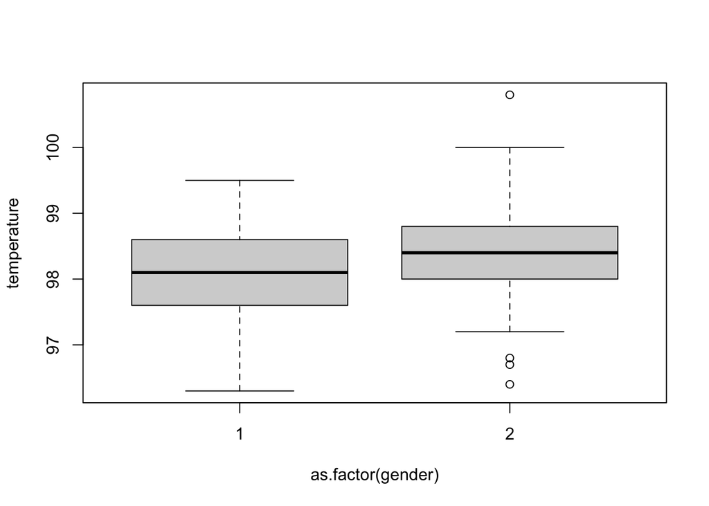

```r
boxplot(temperature~as.factor(gender), data = normtemp)
```

```r
data("normtemp")
m <- subset(normtemp, gender == 1)
f <- subset(normtemp, gender == 2)
wilcox.test(m$temperature, f$temperature, alternative = "two.sided")
```

```
##
##  Wilcoxon rank sum test with continuity correction
##
## data:  m$temperature and f$temperature
## W = 1637, p-value = 0.02676
## alternative hypothesis: true location shift is not equal to 0
```

With a p-value of 0.02676, we have sufficient statistical evidence to reject the null hypothesis at a $\alpha = 0.05$ confidence level, and have reason to believe that the median of the two groups is different.